# Introduction to the course

PSCI 2301: Quantitative Political Science II

Prof. Brenton Kenkel

brenton.kenkel@gmail.com

Vanderbilt University

January 6, 2025

## Today’s agenda

1. Introduce myself and the course
2. Go through the syllabus
3. Review necessary software

# Introductions

## About me

Some background:

- “Kenkel” rhymes with “sprinkle” 🧁
- Grew up in Northern Kentucky, near Cincinnati
- Philosophy and political science major at University of Kentucky (2008)
- PhD in political science from University of Rochester (2014)
- On the Vanderbilt faculty since 2014
- Research + classes on international relations, game theory, statistics

Email: brenton.kenkel@gmail.com (preferred over Vanderbilt email)

Office hours: Tuesday 2-4pm, Commons 326, no appointment needed

## About PSCI 2301

The main topic of this course is causal inference

Political scientists, policy analysts, decision makers, regular people —  
all need to answer causal questions

- How much does a party help (or hurt) its general election chances by nominating a moderate?
- How much do get-out-the-vote mailers increase turnout?
- To what extent do border walls reduce contraband smuggling?
- How much will a law degree increase your earning potential?
- Will eating bacon give you cancer?

We’ll study the statistical approach to answering questions like these

## Why causal questions are hard to answer

Does following the news closely make a person more likely to have extreme political views?

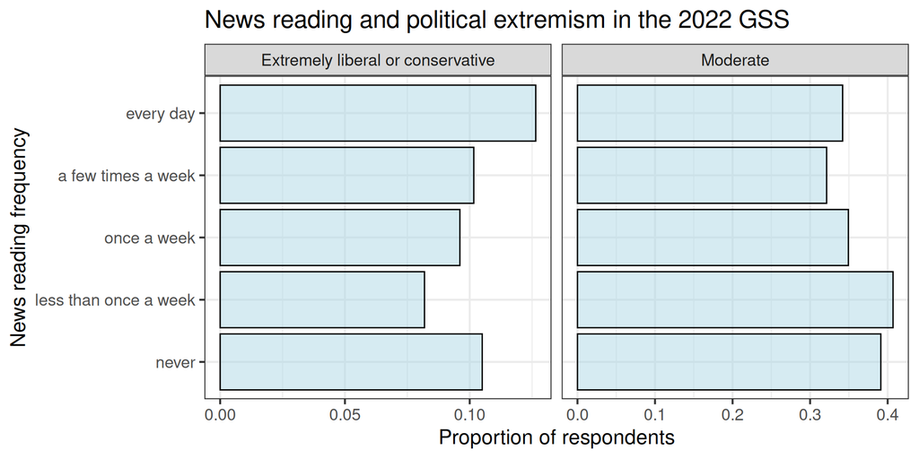

## Why causal questions are hard to answer

Why can’t we just compare those who follow the news to those who don’t?

What we want to know: If we took the **same people** and changed their news consumption, how would their views change?

But the news followers and non-followers are **different people**

One correlation, many viable explanations

1. Maybe following the news really does polarize people
2. Maybe already-extreme people are more interested in the news
3. Maybe some other factors—education, income, personality type—shape both news consumption and extremism
4. Maybe all of these are true!

## What we’re going to do

### The statistical approach to causal inference

We can’t observe the same people as news followers and non-followers

But we can try to compare groups that are as similar as possible

- Experimental: Randomly assign who does and doesn’t follow
- Observational: Measure confounding variables and use statistical adjustments to eliminate their influence
- Hybrid: Isolate **seemingly random** differences in news consumption

Most current research — and much of this course — uses the hybrid approach to causal inference

# The syllabus

## Is this course right for you? A checklist

- You’re interested in using data to answer causal questions
- You have a working familiarity with R from DS 1000 or PSCI 2300
- You’re comfortable with math at the level of high school algebra
- You’re willing to invest substantial time out of the classroom to learn the material
- You’re eager to write a research paper that will require significant work and advance planning
- You’re okay with uncertainty and are willing to revise your beliefs

## Readings

Required book:

[figure not shown]

Typical weekly reading schedule

1. Chapter of *MM*, or similar stats content
2. Polisci article applying those methods

How I’d approach weekly readings

- Skim all before Monday’s class
- Polisci article first, then stats stuff
- Note questions for class/Brightspace discussions
- Go back and do a deeper reread after Wednesday’s class

## Problem sets

Five sets, roughly evenly spaced over the semester

Not just code — you’ll need to think about causal relationships

Learning by doing $\leadsto$ expect a **substantial time investment** on each set

Lowest score dropped, other four each worth 12.5% of grade

One-time-use, 72-hour extension policy

Peer collaboration allowed, but turn in your own writeup, no rote copying

## Final research project

You’ll use statistics to answer a causal question about politics

Final paper will be a scientific report, in the style of the polisci readings

No page requirement, but I imagine you’ll end up around 20 pages

- February 28: Proposal for topics and data (10% of final grade)
- March 28: Complete first draft (10%)
- April 14/16: In-class presentation (5%)
- April 23: Final paper (20%) and revision memo (5%)

Start looking into topics and data availability asap  
(seriously, do not procrastinate on this)

## Generative AI policy

You can use ChatGPT, vanderbilt.ai, etc., in any capacity

Think of AI as a complement to learning, not a substitute

You are ultimately responsible for whatever you turn in

My personal experiences with generative AI in a stats/research setting

- Writing code 🙂 (especially with Copilot)
- Answering code questions 🙂
- Critiquing and correcting my prose writing 😐
- Writing prose on its own 😖
- Coming up with research topic ideas 🤮

## Extra credit

Ways to earn up to 3% extra credit

1. Post questions on Brightspace discussions
2. Answer other people’s questions on Brightspace discussions
3. Regularly ask questions in class

# Software

## R and RStudio

R download: https://cran.rstudio.com/

RStudio download: https://posit.co/download/rstudio-desktop/

Required R setup: (only need to run once)

```r
install.packages("tidyverse")
install.packages("tinytex")
tinytex::install_tinytex()
```

Pretty much all stats in this course could also be done in Python, but R still most common in political science

## Quarto

Quarto $\approx$ R Markdown + additional features + Python compatibility

Download link: https://quarto.org/docs/download/

You’ll complete problem sets using Quarto

Lecture slide Quarto code at https://github.com/brentonk/psci2301_slides

# Wrapping up

## To do for next time

1. Get all software installed
2. Double check that you can render `hello_world.qmd` to PDF
3. If you need an R refresher, look at intro R notes from PSCI 2300 posted for this week on Brightspace